# This is Assignment 10 - Thienkim Le

## Requirement

Create a one-dimensional NumPy array named one_d_array of 20 random numbers with values between 1 – 10. Demonstrate the following comparison operators as universal functions: • <, >, <=, >=, !=, and ==

```python
import numpy as np

# Create a one-dimensional NumPy array of 20 random numbers between 1 and 10
one_d_array = np.random.randint(1, 11, size=20)

print("Original array:")
print(one_d_array)

# Comparison operators as universal functions
print("\nComparison results:")
print("Less than 5:\n", np.less(one_d_array, 5))
print("Greater than 5:\n", np.greater(one_d_array, 5))
print("Less than or equal to 5:\n", np.less_equal(one_d_array, 5))
print("Greater than or equal to 5:\n", np.greater_equal(one_d_array, 5))
print("Not equal to 5:\n", np.not_equal(one_d_array, 5))
print("Equal to 5:\n", np.equal(one_d_array, 5))
```

```
Original array:
[ 4  6  9 10  5  7  1  7  1  9  8  8 10  7  1  4  6  8  7  6]

Comparison results:
Less than 5:
 [ True False False False False False  True False  True False False False
 False False  True  True False False False False]
Greater than 5:
 [False  True  True  True False  True False  True False  True  True  True
  True  True False False  True  True  True  True]
Less than or equal to 5:
 [ True False False False  True False  True False  True False False False
 False False  True  True False False False False]
Greater than or equal to 5:
 [False  True  True  True  True  True False  True False  True  True  True
  True  True False False  True  True  True  True]
Not equal to 5:
 [ True  True  True  True False  True  True  True  True  True  True  True
  True  True  True  True  True  True  True  True]
Equal to 5:
 [False False False False  True False False False False False False False
 False False False False False False False False]
```

## Requirement 4

Create a two-dimensional NumPy array named two_d_array size = (4,5) with any values between 11 – 34. Demonstrate the following comparison operators as universal functions:

- <, >, <=, >=, !=, and ==
- count the values < 15
- sum the values > 20
- count the values >= 19 in each row
- determine if any values < 12
- determine if all values > 12
- determine if all values in each column > 14

```python
import numpy as np

# Create a two-dimensional NumPy array of size (4,5) with random values between 11 and 34
two_d_array = np.random.randint(11, 35, size=(4, 5))

print("Original array:")
print(two_d_array)

# Comparison operators as universal functions
print("\nComparison results:")
print("Less than 15:\n", np.less(two_d_array, 15))
print("Greater than 15:\n", np.greater(two_d_array, 15))
print("Less than or equal to 15:\n", np.less_equal(two_d_array, 15))
print("Greater than or equal to 15:\n", np.greater_equal(two_d_array, 15))
print("Not equal to 15:\n", np.not_equal(two_d_array, 15))
print("Equal to 15:\n", np.equal(two_d_array, 15))

# Count values less than 15
print("\nCount of values less than 15: ", np.count_nonzero(two_d_array < 15))

# Sum values greater than 20
print("Sum of values greater than 20: ", np.sum(two_d_array[two_d_array > 20]))

# Count values greater than or equal to 19 in each row
print("\nCount of values >= 19 in each row: ")
print(np.sum(two_d_array >= 19, axis=1))

# Determine if any values are less than 12
print("\nAny values less than 12:", np.any(two_d_array < 12))

# Determine if all values are greater than 12
print("All values greater than 12:", np.all(two_d_array > 12))

# Determine if all values in each column are greater than 14
print("All values in each column greater than 14:")
print(np.all(two_d_array > 14, axis=0))
```

```
Original array:
[[21 29 23 23 13]
 [12 14 16 32 20]
 [27 13 24 29 30]
 [22 30 19 30 12]]

Comparison results:
Less than 15:
 [[False False False False  True]
 [ True  True False False False]
 [False  True False False False]
 [False False False False  True]]
Greater than 15:
 [[ True  True  True  True False]
 [False False  True  True  True]
 [ True False  True  True  True]
 [ True  True  True  True False]]
Less than or equal to 15:
 [[False False False False  True]
 [ True  True False False False]
 [False  True False False False]
 [False False False False  True]]
Greater than or equal to 15:
 [[ True  True  True  True False]
 [False False  True  True  True]
 [ True False  True  True  True]
 [ True  True  True  True False]]
Not equal to 15:
 [[ True  True  True  True  True]
 [ True  True  True  True  True]
 [ True  True  True  True  True]
 [ True  True  True  True  True]]
Equal to 15:
 [[False False False False False]
 [False False False False False]
 [False False False False False]
 [False False False False False]]

Count of values less than 15:  5
Sum of values greater than 20:  320

Count of values >= 19 in each row:
[4 2 4 4]

Any values less than 12: False
All values greater than 12: False
All values in each column greater than 14:
[False False  True  True False]
```

## Requirement 5

Using the inches array from Chapter 02.06, determine the number of values where:

- 0.15 <= value <= 1.15
- Use ~ and | to return the same number as & above

```python
import numpy as np

# Seattle averages 0.10958904in of rainfall per day. That is .278cm == 2.78mm.
inches = pd.read_csv('Seattle2014.csv')['PRCP'].values

inches = rainfall / 254.0  # 254.0 is cmx100 (or mmx10).
print("\nSeatle 2014 Rainfall-Converted to inches: \n")
print(inches)

# Create boolean masks for lower and upper bounds
lower_bound_mask = (0.15 <= inches)
upper_bound_mask = (inches <= 1.15)

# Combine the masks using bitwise AND (&)
combined_mask = lower_bound_mask & upper_bound_mask

# Count the number of True values in the combined mask
count_values = np.sum(combined_mask)

print("\nNumber of values between 0.15 and 1.15 inches:", count_values)

# Alternatively, count the number of True values using np.count_nonzero
alt_count_values = np.count_nonzero(combined_mask)

print("\nAlternative count of values between 0.15 and 1.15 inches:", alt_count_values)

# Print the values between 0.15 and 1.15 inches
values_between = inches[combined_mask]
print("\nValues between 0.15 and 1.15 inches:\n", values_between)
```

```
Seatle 2014 Rainfall-Converted to inches:

[0.         0.16141732 0.05905512 0.         0.         0.01181102
 0.48031496 0.38188976 0.22834646 0.16929134 0.83858268 0.05905512
 0.         0.         0.         0.         0.         0.
 0.         0.         0.         0.01968504 0.         0.
 0.         0.         0.         0.3503937  0.8503937  0.
 0.09055118 0.07874016 0.         0.         0.         0.
 0.         0.         0.2007874  0.01968504 0.72047244 0.66929134
 0.18110236 0.07086614 0.37007874 0.46062992 1.03937008 0.57086614
 0.5984252  0.03937008 0.11811024 0.11023622 0.0984252  0.24015748
 0.51181102 0.01181102 0.         0.         0.         0.01968504
 0.7519685  0.42125984 0.6496063  1.83858268 0.11811024 0.
 1.27165354 0.16929134 0.74015748 0.         0.         0.01968504
 0.27165354 0.31889764 1.09055118 0.01181102 0.         0.01968504
 0.         0.         0.         0.         0.         0.16141732
 0.14173228 0.01181102 0.87007874 0.5511811  0.         0.
 0.         0.         0.0984252  0.         0.18110236 0.
 0.         0.18110236 0.         0.         0.         0.
 0.         0.         0.01968504 0.42913386 0.72834646 0.
 0.53937008 0.         0.2007874  0.55905512 0.3503937  0.48818898
 0.         0.12992126 0.27165354 0.         0.         0.
 0.         0.         1.31102362 0.62992126 0.2007874  0.
 0.         0.53937008 0.07874016 0.01968504 0.         0.
 0.         0.         0.         0.         0.         0.
 0.         0.         0.         0.         0.1496063  0.
 0.22047244 0.         0.         0.         0.         0.
 0.         0.         0.         0.         0.         0.
 0.         0.         0.         0.         0.         0.
 0.07086614 0.2519685  0.         0.01968504 0.14173228 0.0511811
 0.         0.03149606 0.01181102 0.         0.         0.
 0.         0.         0.         0.07086614 0.09055118 0.
 0.         0.         0.         0.         0.         0.
 0.         0.         0.         0.         0.         0.
 0.         0.         0.         0.         0.         0.
 0.         0.         0.         0.         0.01181102 0.75984252
 0.         0.         0.         0.         0.         0.
 0.         0.         0.         0.01968504 0.         0.
 0.         0.         0.         0.         0.         0.
 0.01968504 0.5        0.8503937  0.         0.03937008 0.
```

[output cut: 28 more lines]

```
Values between 0.15 and 1.15 inches:
 [0.16141732 0.48031496 0.38188976 0.22834646 0.16929134 0.83858268
 0.3503937  0.8503937  0.2007874  0.72047244 0.66929134 0.18110236
 0.37007874 0.46062992 1.03937008 0.57086614 0.5984252  0.24015748
 0.51181102 0.7519685  0.42125984 0.6496063  0.16929134 0.74015748
 0.27165354 0.31889764 1.09055118 0.16141732 0.87007874 0.5511811
 0.18110236 0.18110236 0.42913386 0.72834646 0.53937008 0.2007874
 0.55905512 0.3503937  0.48818898 0.27165354 0.62992126 0.2007874
 0.53937008 0.22047244 0.2519685  0.75984252 0.5        0.8503937
 0.33070866 0.72047244 0.7992126  0.16929134 0.3503937  0.29133858
 0.2992126  0.27952756 0.33858268 0.59055118 0.46062992 0.37007874
 0.16141732 0.24015748 0.5        1.         0.66929134 0.42913386
 0.16141732 0.18897638 0.16141732 0.2007874  0.5984252  0.46850394
 0.72047244 0.29133858 0.35826772 0.38976378 0.51181102 0.27165354
 0.51181102 0.77165354 0.81102362 0.20866142 0.16141732]
```

## Requirement 6

Using the inches array from Chapter 02.06, show the following:

- Number of days without rain
- Number of days with rain
- Days with >= 1 inch of rain

```python
import numpy as np

# Seattle averages 0.10958904in of rainfall per day. That is .278cm == 2.78mm.
inches = pd.read_csv('Seattle2014.csv')['PRCP'].values

inches = rainfall / 254.0  # 254.0 is cmx100 (or mmx10).
print("\nSeatle 2014 Rainfall-Converted to inches: \n")
print(inches)

# Number of days without rain
days_without_rain = np.sum(inches == 0)

# Number of days with rain
days_with_rain = np.sum(inches > 0)

# Days with >= 1 inch of rain
days_with_one_inch_or_more = np.sum(inches >= 1)

print("Number of days without rain: ", days_without_rain)
print("Number of days with rain: ", days_with_rain)
print("Days with >= 1 inch of rain: ", days_with_one_inch_or_more)
```

```
Seatle 2014 Rainfall-Converted to inches:

[0.         0.16141732 0.05905512 0.         0.         0.01181102
 0.48031496 0.38188976 0.22834646 0.16929134 0.83858268 0.05905512
 0.         0.         0.         0.         0.         0.
 0.         0.         0.         0.01968504 0.         0.
 0.         0.         0.         0.3503937  0.8503937  0.
 0.09055118 0.07874016 0.         0.         0.         0.
 0.         0.         0.2007874  0.01968504 0.72047244 0.66929134
 0.18110236 0.07086614 0.37007874 0.46062992 1.03937008 0.57086614
 0.5984252  0.03937008 0.11811024 0.11023622 0.0984252  0.24015748
 0.51181102 0.01181102 0.         0.         0.         0.01968504
 0.7519685  0.42125984 0.6496063  1.83858268 0.11811024 0.
 1.27165354 0.16929134 0.74015748 0.         0.         0.01968504
 0.27165354 0.31889764 1.09055118 0.01181102 0.         0.01968504
 0.         0.         0.         0.         0.         0.16141732
 0.14173228 0.01181102 0.87007874 0.5511811  0.         0.
 0.         0.         0.0984252  0.         0.18110236 0.
 0.         0.18110236 0.         0.         0.         0.
 0.         0.         0.01968504 0.42913386 0.72834646 0.
 0.53937008 0.         0.2007874  0.55905512 0.3503937  0.48818898
 0.         0.12992126 0.27165354 0.         0.         0.
 0.         0.         1.31102362 0.62992126 0.2007874  0.
 0.         0.53937008 0.07874016 0.01968504 0.         0.
 0.         0.         0.         0.         0.         0.
 0.         0.         0.         0.         0.1496063  0.
 0.22047244 0.         0.         0.         0.         0.
 0.         0.         0.         0.         0.         0.
 0.         0.         0.         0.         0.         0.
 0.07086614 0.2519685  0.         0.01968504 0.14173228 0.0511811
 0.         0.03149606 0.01181102 0.         0.         0.
 0.         0.         0.         0.07086614 0.09055118 0.
 0.         0.         0.         0.         0.         0.
 0.         0.         0.         0.         0.         0.
 0.         0.         0.         0.         0.         0.
 0.         0.         0.         0.         0.01181102 0.75984252
 0.         0.         0.         0.         0.         0.
 0.         0.         0.         0.01968504 0.         0.
 0.         0.         0.         0.         0.         0.
 0.01968504 0.5        0.8503937  0.         0.03937008 0.
```

[output cut: 11 more lines]

```
 1.25984252 0.37007874 0.16141732 0.24015748 0.05905512 0.03149606
 0.5        0.01968504 1.         0.66929134 0.         0.07086614
 0.42913386 0.16141732 0.18897638 0.16141732 0.         0.
 0.2007874  0.         0.         0.         0.         0.
 0.         0.         0.         0.         0.         0.14173228
 0.5984252  0.01968504 0.46850394 0.0511811  0.72047244 0.01181102
 0.12992126 1.3503937  0.14173228 0.         0.         0.
 0.         0.03149606 0.11811024 0.29133858 0.         0.35826772
 0.38976378 0.51181102 0.27165354 0.         0.         0.
 0.         0.         0.11023622 0.51181102 0.11811024 0.77165354
 0.         0.         0.81102362 0.20866142 0.         0.
 0.12992126 0.16141732 0.         0.         0.        ]
Number of days without rain:  215
Number of days with rain:  150
Days with >= 1 inch of rain:  8
```

## Requirement 7

Use Boolean masking on two_d_array to:

- return a Boolean array where < 15
- return an array of values < 15

```python
import numpy as np

# Define a 2D array
two_d_array = np.random.randint(0, 100, size=(4, 5))

print("Two-dimensional array:")
print(two_d_array)

# Boolean array where elements are < 15
boolean_mask = two_d_array < 15

# Array of values < 15
values_less_than_15 = two_d_array[boolean_mask]

print("\nBoolean array where elements are < 15:\n", boolean_mask)
print("\nArray of values < 15:\n", values_less_than_15)
```

```
Two-dimensional array:
[[65 25  1 20 45]
 [75 99  9 76 11]
 [ 9 71 91 48 19]
 [61 74 46 24 26]]

Boolean array where elements are < 15:
 [[False False  True False False]
 [False False  True False  True]
 [ True False False False False]
 [False False False False False]]

Array of values < 15:
 [ 1  9 11  9]
```

## Requirement 8

Using the inches rain data and the following definition (pouring = (inches > 0.5)), output the following data:

- Median precip on pouring days in 2014 (inches):
- Median precip on summer days in 2014 (inches):
- Maximum precip on summer days in 2014 (inches):
- Median precip on non-summer pouring days in 2014 (inches):

```python
import numpy as np

# Seattle averages 0.10958904in of rainfall per day. That is .278cm == 2.78mm.
inches = pd.read_csv('Seattle2014.csv')['PRCP'].values

inches = rainfall / 254.0  # 254.0 is cmx100 (or mmx10).
print("\nSeatle 2014 Rainfall-Converted to inches: \n")
print(inches)

# Define pouring days
pouring = (inches > 0.5)

# Calculate median precipitation on pouring days in 2014
median_pouring_precip = np.median(inches[pouring])

# Define summer days (June to August)
summer_days = (np.arange(365) - 172 < 92) & (np.arange(365) - 172 >= 0)

# Calculate median precipitation on summer days in 2014
median_summer_precip = np.median(inches[summer_days])

# Calculate maximum precipitation on summer days in 2014
max_summer_precip = np.max(inches[summer_days])

# Calculate median precipitation on non-summer pouring days in 2014
non_summer_pouring_precip = inches[pouring & ~summer_days]
median_non_summer_pouring_precip = np.median(non_summer_pouring_precip)

# Output the results
print("\nMedian precip on pouring days in 2014 (inches):", median_pouring_precip)
print("\nMedian precip on summer days in 2014 (inches):", median_summer_precip)
print("\nMaximum precip on summer days in 2014 (inches):", max_summer_precip)
print("\nMedian precip on non-summer pouring days in 2014 (inches):", median_non_summer_pouring_precip)
```

```
Seatle 2014 Rainfall-Converted to inches:

[0.         0.16141732 0.05905512 0.         0.         0.01181102
 0.48031496 0.38188976 0.22834646 0.16929134 0.83858268 0.05905512
 0.         0.         0.         0.         0.         0.
 0.         0.         0.         0.01968504 0.         0.
 0.         0.         0.         0.3503937  0.8503937  0.
 0.09055118 0.07874016 0.         0.         0.         0.
 0.         0.         0.2007874  0.01968504 0.72047244 0.66929134
 0.18110236 0.07086614 0.37007874 0.46062992 1.03937008 0.57086614
 0.5984252  0.03937008 0.11811024 0.11023622 0.0984252  0.24015748
 0.51181102 0.01181102 0.         0.         0.         0.01968504
 0.7519685  0.42125984 0.6496063  1.83858268 0.11811024 0.
 1.27165354 0.16929134 0.74015748 0.         0.         0.01968504
 0.27165354 0.31889764 1.09055118 0.01181102 0.         0.01968504
 0.         0.         0.         0.         0.         0.16141732
 0.14173228 0.01181102 0.87007874 0.5511811  0.         0.
 0.         0.         0.0984252  0.         0.18110236 0.
 0.         0.18110236 0.         0.         0.         0.
 0.         0.         0.01968504 0.42913386 0.72834646 0.
 0.53937008 0.         0.2007874  0.55905512 0.3503937  0.48818898
 0.         0.12992126 0.27165354 0.         0.         0.
 0.         0.         1.31102362 0.62992126 0.2007874  0.
 0.         0.53937008 0.07874016 0.01968504 0.         0.
 0.         0.         0.         0.         0.         0.
 0.         0.         0.         0.         0.1496063  0.
 0.22047244 0.         0.         0.         0.         0.
 0.         0.         0.         0.         0.         0.
 0.         0.         0.         0.         0.         0.
 0.07086614 0.2519685  0.         0.01968504 0.14173228 0.0511811
 0.         0.03149606 0.01181102 0.         0.         0.
 0.         0.         0.         0.07086614 0.09055118 0.
 0.         0.         0.         0.         0.         0.
 0.         0.         0.         0.         0.         0.
 0.         0.         0.         0.         0.         0.
 0.         0.         0.         0.         0.01181102 0.75984252
 0.         0.         0.         0.         0.         0.
 0.         0.         0.         0.01968504 0.         0.
 0.         0.         0.         0.         0.         0.
 0.01968504 0.5        0.8503937  0.         0.03937008 0.
```

[output cut: 16 more lines]

```
 0.5984252  0.01968504 0.46850394 0.0511811  0.72047244 0.01181102
 0.12992126 1.3503937  0.14173228 0.         0.         0.
 0.         0.03149606 0.11811024 0.29133858 0.         0.35826772
 0.38976378 0.51181102 0.27165354 0.         0.         0.
 0.         0.         0.11023622 0.51181102 0.11811024 0.77165354
 0.         0.         0.81102362 0.20866142 0.         0.
 0.12992126 0.16141732 0.         0.         0.        ]

Median precip on pouring days in 2014 (inches): 0.7283464566929134

Median precip on summer days in 2014 (inches): 0.0

Maximum precip on summer days in 2014 (inches): 0.8503937007874016

Median precip on non-summer pouring days in 2014 (inches): 0.7204724409448819
```

## Requirement 9

In your own words, explain the difference between the keywords and and or and the operators & and |. When are the keywords used and when are the operators used?

The keywords and and or are used for boolean operations in Python. They are used to combine multiple conditions or expressions and evaluate them together.

- and: It returns True if both conditions or expressions on its left and right sides are True.
- or: It returns True if at least one of the conditions or expressions on its left and right sides is True.

The operators & and |, on the other hand, are bitwise operators in Python. They perform bitwise operations on integers and bitwise logical operations on boolean arrays.

- &: It performs a bitwise AND operation. When used with boolean arrays, it performs element-wise AND operation.
- |: It performs a bitwise OR operation. When used with boolean arrays, it performs element-wise OR operation.

Here's a summary of when to use each:

- Use 'and' and 'or' when you want to combine boolean conditions or expressions in Python code.
- Use '&' and '|' when you want to perform element-wise logical operations on boolean arrays in NumPy or when you want to perform bitwise operations on integers.

Here are examples illustrating the usage of both:

```python
import numpy as np

# Using 'and' keyword
x = 5
y = 10
c = -2
if x > 0 and y > 0:
    print("Both x and y are greater than 0: ", x, y)
if x > 0 or c > 0:
    print("At least one of x and y is greater than 0: ",x,c)

arr1 = np.array([True, False, True])
arr2 = np.array([False, True, True])

# Using '&' operator
result = arr1 & arr2
print("Result of element-wise AND operation:", result)

# Using '|' operator
result = arr1 | arr2
print("Result of element-wise OR operation:", result)
```

```
Both x and y are greater than 0:  5 10
At least one of x and y is greater than 0:  5 -2
Result of element-wise AND operation: [False False  True]
Result of element-wise OR operation: [ True  True  True]
```

## Requirement 10

Demonstrate fancy indexing with:

- one_d_array
- two_d_array

```python
import numpy as np

# Define a one-dimensional array
one_d_array = np.array([10, 20, 30, 40, 50])

# Define a two-dimensional array
two_d_array = np.array([[1, 2, 3],
                        [4, 5, 6],
                        [7, 8, 9]])

# Fancy indexing with one_d_array
indices = np.array([0, 2, 4])  # Array of indices to access elements at index 0, 2, and 4
selected_elements = one_d_array[indices]
print("Selected elements from one_d_array:", selected_elements)

# Fancy indexing with two_d_array
rows = np.array([0, 1, 2])      # Rows to access: 0th, 1st, and 2nd rows
cols = np.array([0, 2, 1])      # Columns to access: 0th, 2nd, and 1st columns
selected_elements = two_d_array[rows, cols]
print("Selected elements from two_d_array:", selected_elements)
```

```
Selected elements from one_d_array: [10 30 50]
Selected elements from two_d_array: [1 6 8]
```

## Requirement 11

Demonstrate combined indexing with:

- two_d_array and slicing
- two_d_array and masking

```python
import numpy as np

# Define a two-dimensional array
two_d_array = np.array([[1, 2, 3],
                        [4, 5, 6],
                        [7, 8, 9]])

# Combined indexing with slicing and masking

# Select elements from the second row (index 1) where the value is greater than 3
selected_elements = two_d_array[1, two_d_array[1, :] > 3]

print("Original two-dimensional array:")
print(two_d_array)
print("\nSelected elements using combined indexing:")
print(selected_elements)
```

```
Original two-dimensional array:
[[1 2 3]
 [4 5 6]
 [7 8 9]]

Selected elements using combined indexing:
[4 5 6]
```

## Requirement 12

Demonstrate the following using two_d_array:

- sort each row
- sort each column
- partition the array such that the first three values in each column are the lowest values in that column

```python
import numpy as np

# Create a 2D array
two_d_array = np.array([[5, 3, 7, 2],
                        [1, 9, 4, 6],
                        [8, 0, 2, 4]])

# Sort each row
sorted_rows = np.sort(two_d_array, axis=1)
print("Sorted rows:")
print(sorted_rows)

# Sort each column
sorted_columns = np.sort(two_d_array, axis=0)
print("\nSorted columns:")
print(sorted_columns)

# Partition the array such that the first three values in each column are the lowest values in that column
partitioned_array = np.partition(two_d_array, 2, axis=0)
print("\nPartitioned array:")
print(partitioned_array)
```

```
Sorted rows:
[[2 3 5 7]
 [1 4 6 9]
 [0 2 4 8]]

Sorted columns:
[[1 0 2 2]
 [5 3 4 4]
 [8 9 7 6]]

Partitioned array:
[[1 0 2 2]
 [5 3 4 4]
 [8 9 7 6]]
```

## Requirement 13

Produce a k-nearest neighbor plot using:

- a 25 X 2 array
- K = 3

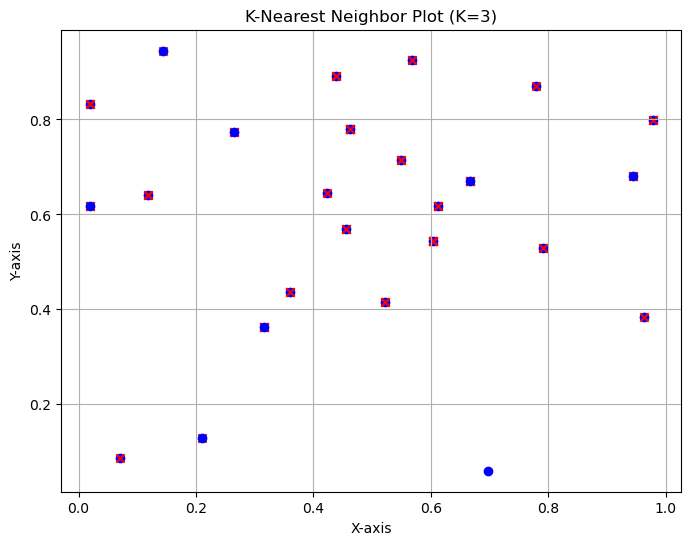

```python
import numpy as np
import matplotlib.pyplot as plt
from sklearn.neighbors import NearestNeighbors

# Generating random data for demonstration
np.random.seed(0)
data = np.random.rand(25, 2)

# Creating a NearestNeighbors model with k=3
k = 3
nbrs = NearestNeighbors(n_neighbors=k, algorithm='ball_tree').fit(data)

# Finding the k-nearest neighbors for each point
distances, indices = nbrs.kneighbors(data)

# Plotting the k-nearest neighbor plot
plt.figure(figsize=(8, 6))
for i in range(len(data)):
    plt.scatter(data[i, 0], data[i, 1], color='blue', marker='o')  # Plotting the data point
    neighbors = data[indices[i][1:]]  # Excluding the first point (itself)
    plt.scatter(neighbors[:, 0], neighbors[:, 1], color='red', marker='x')  # Plotting the neighbors
plt.title('K-Nearest Neighbor Plot (K=3)')
plt.xlabel('X-axis')
plt.ylabel('Y-axis')
plt.grid(True)
plt.show()
```

## Requirement 14

Create a structured array named super_heroes using:

- the dictionary method
- NumPy data types for the element names
- with the following element names:
  - i. name
  - ii. age
  - iii. birthplace iv. super_power

```python
import numpy as np

# Define the data types for the structured array
dtypes = [('name', 'U50'),  # U50 represents a Unicode string of maximum length 50
          ('age', int),
          ('birthplace', 'U50'),
          ('super_power', 'U50')]

# Define data for super_heroes as a list of tuples
data = [
    ('Superman', 30, 'Krypton', 'Flight'),
    ('Batman', 35, 'Gotham City', 'Intelligence'),
    ('Wonder Woman', 28, 'Themyscira', 'Strength')
]

# Create the structured array using the dictionary method
super_heroes = np.array(data, dtype=dtypes)

# Print the structured array
print(super_heroes)
```

```
[('Superman', 30, 'Krypton', 'Flight')
 ('Batman', 35, 'Gotham City', 'Intelligence')
 ('Wonder Woman', 28, 'Themyscira', 'Strength')]
```

## Requirement 15

Use markdown to include a statement at the end of assignment-10.ipynb explaining your experiences with Assignment 10. Make this authentic (minimum of 2-3 sentences).

Assignment 10 was an engaging and rewarding experience that allowed me to consolidate my understanding of NumPy operations and data manipulation techniques. Through the tasks provided, I was able to apply concepts such as boolean masking, fancy indexing, and array manipulation to solve practical problems. The combination of theoretical knowledge and hands-on practice enhanced my proficiency in using NumPy for data analysis and manipulation, further solidifying my skills in Python programming for data science.